# Final_Maverik_EDA_v3

## Food Service Sales by Categorical Variables

### Food Service Sales by Stores that sell Cinnabon

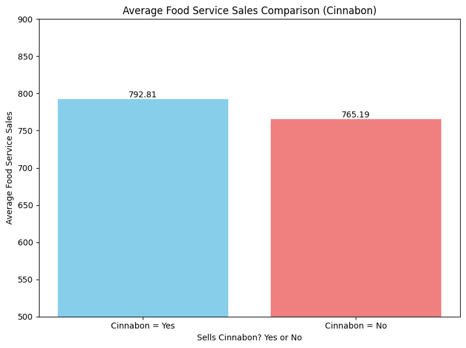

```python
# # Filter the DataFrame to select stores that have and don't have'cinnabon'
cinnabon_stores = df[df['cinnabon'] == 'Yes']['daily_yoy_ndt.total_food_service'].mean()
no_cinnabon_stores = df[df['cinnabon'] == 'No']['daily_yoy_ndt.total_food_service'].mean()

# Create a bar chart to compare average sales
plt.figure(figsize=(8, 6))
plt.ylim(500, 900)
bars = plt.bar(['Cinnabon = Yes', 'Cinnabon = No'], [cinnabon_stores, no_cinnabon_stores], color=['skyblue', 'lightcoral'])
plt.title('Average Food Service Sales Comparison (Cinnabon)')
plt.xlabel('Sells Cinnabon? Yes or No')
plt.ylabel('Average Food Service Sales')
for bar in bars:
    height = bar.get_height()
    plt.text(bar.get_x() + bar.get_width() / 2, height, f'{height:.2f}', ha='center', va='bottom', fontsize=10)
plt.tight_layout()

# Show the chart
plt.show()
```

It seems that Maverik stores that sells Cinnabons do produce higher average food service sales, however it's not significant enough to say that it drives higher food service sales in general.

### Food Service Sales by Stores that sell lotteries

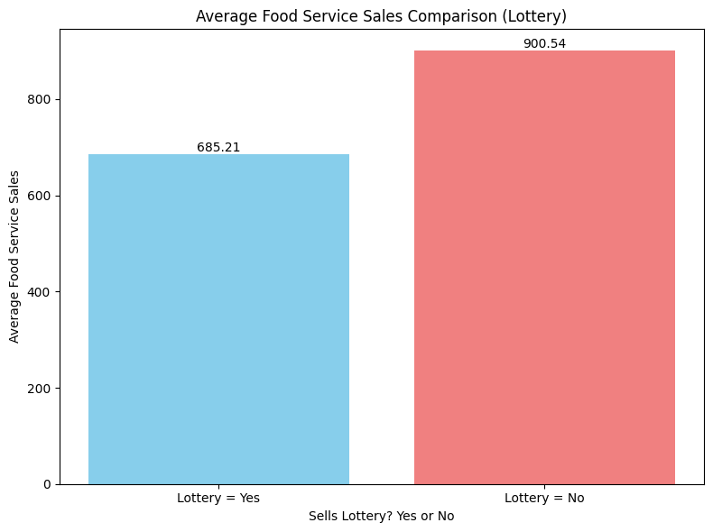

```python
# # Filter the DataFrame to select stores that have and don't have'lottery'
lottery_stores = df[df['lottery'] == 'Yes']['daily_yoy_ndt.total_food_service'].mean()
no_lottery_stores = df[df['lottery'] == 'No']['daily_yoy_ndt.total_food_service'].mean()

# Create a bar chart to compare average sales
plt.figure(figsize=(8, 6))
# plt.ylim(500, 900)
bars = plt.bar(['Lottery = Yes', 'Lottery = No'], [lottery_stores, no_lottery_stores], color=['skyblue', 'lightcoral'])
plt.title('Average Food Service Sales Comparison (Lottery)')
plt.xlabel('Sells Lottery? Yes or No')
plt.ylabel('Average Food Service Sales')
for bar in bars:
    height = bar.get_height()
    plt.text(bar.get_x() + bar.get_width() / 2, height, f'{height:.2f}', ha='center', va='bottom', fontsize=10)
plt.tight_layout()

# Show the chart
plt.show()
```

Total Food Service Sales seem to to be higher on average for stores that don't sell lotteries vs stores that do sell lotteries

### Food Service Sales by Stores that sell F'Real

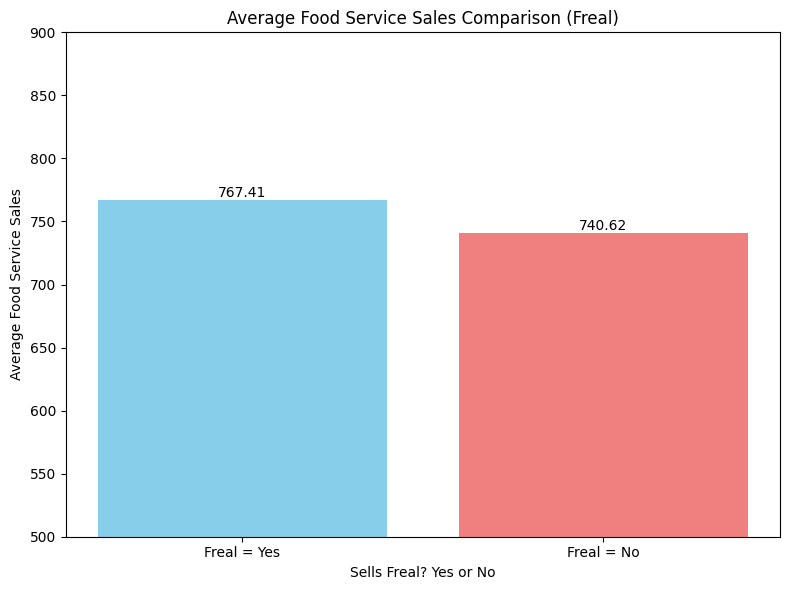

```python
# # Filter the DataFrame to select stores that have and don't have'freal'
freal_stores = df[df['freal'] == 'Yes']['daily_yoy_ndt.total_food_service'].mean()
no_freal_stores = df[df['freal'] == 'No']['daily_yoy_ndt.total_food_service'].mean()

# Create a bar chart to compare average sales
plt.figure(figsize=(8, 6))
plt.ylim(500, 900)
bars = plt.bar(['Freal = Yes', 'Freal = No'], [freal_stores, no_freal_stores], color=['skyblue', 'lightcoral'])
plt.title('Average Food Service Sales Comparison (Freal)')
plt.xlabel('Sells Freal? Yes or No')
plt.ylabel('Average Food Service Sales')
for bar in bars:
    height = bar.get_height()
    plt.text(bar.get_x() + bar.get_width() / 2, height, f'{height:.2f}', ha='center', va='bottom', fontsize=10)
plt.tight_layout()

# Show the chart
plt.show()
```

In our datasets, only one store doesn't sell f'real. Yet, selling f'real doesn't significantly drive food service sales for Maverik stores.

### Food Service Sales by Stores that sell Bonfire Grill

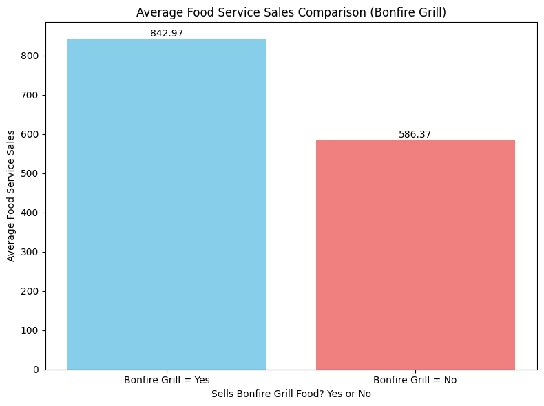

```python
# # Filter the DataFrame to select stores that have and don't have'bonfire grill'
bonfire_stores = df[df['bonfire_grill'] == 'Yes']['daily_yoy_ndt.total_food_service'].mean()
no_bonfire_stores = df[df['bonfire_grill'] == 'No']['daily_yoy_ndt.total_food_service'].mean()

# Create a bar chart to compare average sales
plt.figure(figsize=(8, 6))
# plt.ylim(500, 900)
bars = plt.bar(['Bonfire Grill = Yes', 'Bonfire Grill = No'], [bonfire_stores, no_bonfire_stores], color=['skyblue', 'lightcoral'])
plt.title('Average Food Service Sales Comparison (Bonfire Grill)')
plt.xlabel('Sells Bonfire Grill Food? Yes or No')
plt.ylabel('Average Food Service Sales')
for bar in bars:
    height = bar.get_height()
    plt.text(bar.get_x() + bar.get_width() / 2, height, f'{height:.2f}', ha='center', va='bottom', fontsize=10)
plt.tight_layout()

# Show the chart
plt.show()
```

Stores that sell bonfire grill food seems to drive higher food service sales relative stores that don't sell bonfire grill food.

### Food Service Sales by Stores that sell Pizza

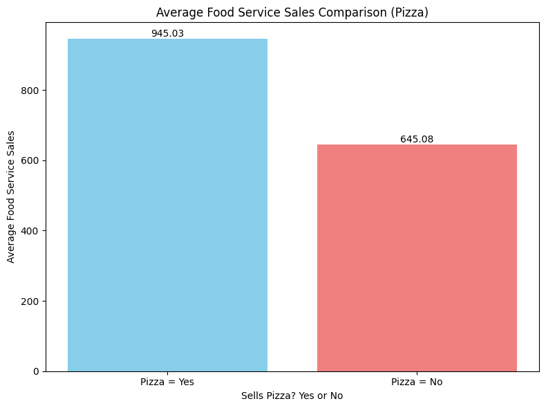

```python
# # Filter the DataFrame to select stores that have and don't have'pizza'
pizza_stores = df[df['pizza'] == 'Yes']['daily_yoy_ndt.total_food_service'].mean()
no_pizza_stores = df[df['pizza'] == 'No']['daily_yoy_ndt.total_food_service'].mean()

# Create a bar chart to compare average sales
plt.figure(figsize=(8, 6))
# plt.ylim(500, 900)
bars = plt.bar(['Pizza = Yes', 'Pizza = No'], [pizza_stores, no_pizza_stores], color=['skyblue', 'lightcoral'])
plt.title('Average Food Service Sales Comparison (Pizza)')
plt.xlabel('Sells Pizza? Yes or No')
plt.ylabel('Average Food Service Sales')
for bar in bars:
    height = bar.get_height()
    plt.text(bar.get_x() + bar.get_width() / 2, height, f'{height:.2f}', ha='center', va='bottom', fontsize=10)
plt.tight_layout()

# Show the chart
plt.show()
```

Stores that sell pizza drives higher food service sales.

### Food Service Sales by Stores that have RV Lanes

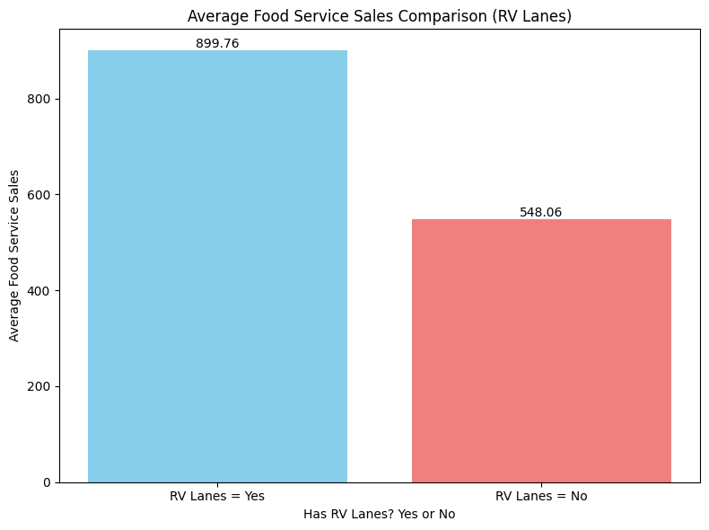

```python
# # Filter the DataFrame to select stores that have and don't have'rv lanes'
rv_stores = df[df['rv_lanes'] == 'Yes']['daily_yoy_ndt.total_food_service'].mean()
no_rv_stores = df[df['rv_lanes'] == 'No']['daily_yoy_ndt.total_food_service'].mean()

# Create a bar chart to compare average sales
plt.figure(figsize=(8, 6))
# plt.ylim(500, 900)
bars = plt.bar(['RV Lanes = Yes', 'RV Lanes = No'], [rv_stores, no_rv_stores], color=['skyblue', 'lightcoral'])
plt.title('Average Food Service Sales Comparison (RV Lanes)')
plt.xlabel('Has RV Lanes? Yes or No')
plt.ylabel('Average Food Service Sales')
for bar in bars:
    height = bar.get_height()
    plt.text(bar.get_x() + bar.get_width() / 2, height, f'{height:.2f}', ha='center', va='bottom', fontsize=10)
plt.tight_layout()

# Show the chart
plt.show()
```

Stores that have RV Lanes experience higher food service sales than stores that don't

## Correlations

### Correlations between the 4 sales metrics

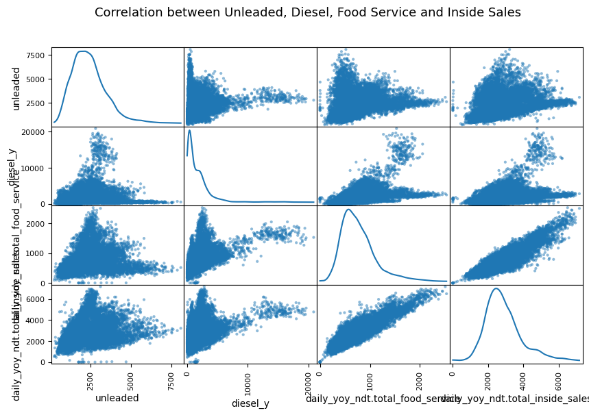

```python
scatter_matrix(df[['unleaded','diesel_y',
                       'daily_yoy_ndt.total_food_service',
                       'daily_yoy_ndt.total_inside_sales']], alpha=0.5, figsize=(10, 6), diagonal='kde')
plt.suptitle('Correlation between Unleaded, Diesel, Food Service and Inside Sales', fontsize=13)
```

Overall, every sales metric is positively correlated to each other. The highest correlation is between inside sales and food service sales.

### Each sales metric with its 7 strongest correlations

```python
df_corr = pd.get_dummies(df)
df_corr.columns
```

```
Index(['open_year', 'square_feet', 'front_door_count',
       'years_since_last_project', 'parking_spaces', 'x1_mile_pop',
       'x1_mile_emp', 'x1_mile_income', 'x1_2_mile_pop', 'x1_2_mile_emp',
       ...
       'calendar_information.holiday_New Year's Eve',
       'calendar_information.holiday_Palm Sunday',
       'calendar_information.holiday_President's Day',
       'calendar_information.holiday_Saint Patrick's Day',
       'calendar_information.holiday_Saint Valentine's Day',
       'calendar_information.holiday_Thanksgiving Day',
       'calendar_information.holiday_Veteran's Day',
       'calendar_information.holiday_Washington's Birthday',
       'calendar_information.type_of_day_WEEKDAY',
       'calendar_information.type_of_day_WEEKEND'],
      dtype='object', length=123)
```

```python
# Create a dictionary to store the top 7 (by magnitude only) correlated columns for each sales metric.
top_correlation_cols = {}

# Loop through each sales metric.
for sales_metric in ['daily_yoy_ndt.total_inside_sales','unleaded','diesel_y','daily_yoy_ndt.total_food_service']:
    correlations = df_corr.corr()[sales_metric].abs()
    top_corr_cols = correlations[correlations.index != sales_metric].nlargest(7).index.tolist()
    top_correlation_cols[sales_metric] = top_corr_cols
```

```python
top_correlation_cols
```

```
{'daily_yoy_ndt.total_inside_sales': ['daily_yoy_ndt.total_food_service',
  'diesel_y',
  'pizza_No',
  'pizza_Yes',
  'rv_lanes_No',
  'def_No',
  'rv_lanes_layout_None'],
 'unleaded': ['lottery_Yes',
  'lottery_No',
  'daily_yoy_ndt.total_inside_sales',
  'x7_min_emp',
  'open_year',
  'x5_min_emp',
  'x7_min_pop'],
 'diesel_y': ['hi_flow_lanes_fueling_positions',
  'hi_flow_lanes_fueling_positions_2',
  'mens_urinal_count',
  'mens_toilet_count',
  'womens_sink_count',
  'daily_yoy_ndt.total_food_service',
  'hi_flow_lanes_Yes'],
 'daily_yoy_ndt.total_food_service': ['daily_yoy_ndt.total_inside_sales',
  'diesel_y',
  'hi_flow_lanes_fueling_positions',
  'hi_flow_lanes_fueling_positions_2',
  'hi_flow_lanes_Yes',
  'hi_flow_rv_lanes_Yes',
  'rv_lanes_layout_Stack']}
```

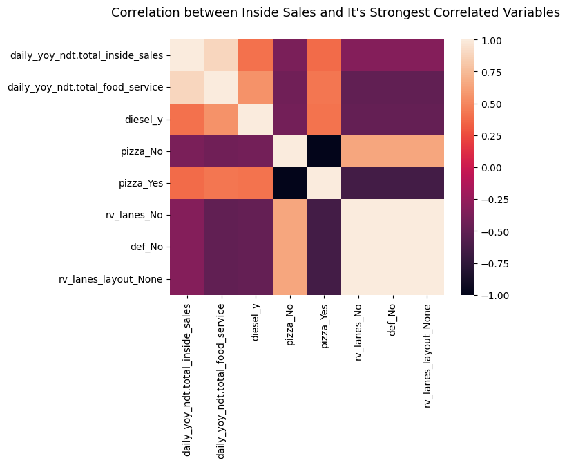

```python
corr_inside = df_corr[['daily_yoy_ndt.total_inside_sales',
                      'daily_yoy_ndt.total_food_service',
  'diesel_y',
  'pizza_No',
  'pizza_Yes',
  'rv_lanes_No',
  'def_No',
  'rv_lanes_layout_None']]
sns.heatmap(corr_inside.corr())
plt.suptitle('Correlation between Inside Sales and It\'s Strongest Correlated Variables', fontsize=13)
```

This correlation plot shows the variables with the highest correlation to inside sales. Specifically, stores selling pizza has a strong positive correlation to inside sales.

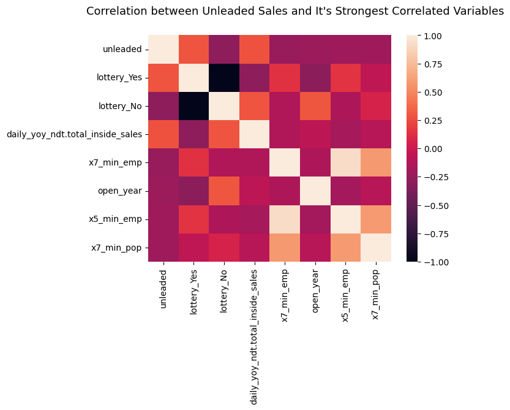

```python
corr_unleaded = df_corr[['unleaded',
                        'lottery_Yes',
  'lottery_No',
  'daily_yoy_ndt.total_inside_sales',
  'x7_min_emp',
  'open_year',
  'x5_min_emp',
  'x7_min_pop']]
sns.heatmap(corr_unleaded.corr())
plt.suptitle('Correlation between Unleaded Sales and It\'s Strongest Correlated Variables', fontsize=13)
```

This correlation plot shows the variables with the highest correlation to unleaded sales. Unleaded sales have the strongest correlation with whether a store sells lottery or not.

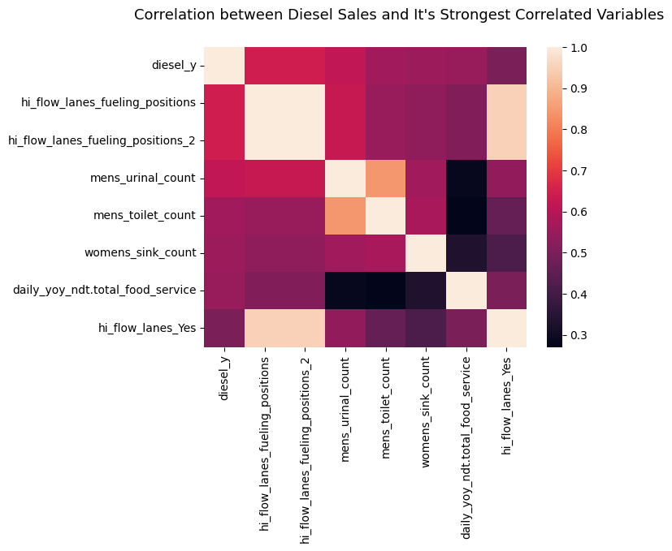

```python
corr_diesel = df_corr[['diesel_y',
                    'hi_flow_lanes_fueling_positions',
  'hi_flow_lanes_fueling_positions_2',
  'mens_urinal_count',
  'mens_toilet_count',
  'womens_sink_count',
  'daily_yoy_ndt.total_food_service',
  'hi_flow_lanes_Yes']]
sns.heatmap(corr_diesel.corr())
plt.suptitle('Correlation between Diesel Sales and It\'s Strongest Correlated Variables', fontsize=13)
```

This correlation plot shows the variables with the highest correlation to diesel.

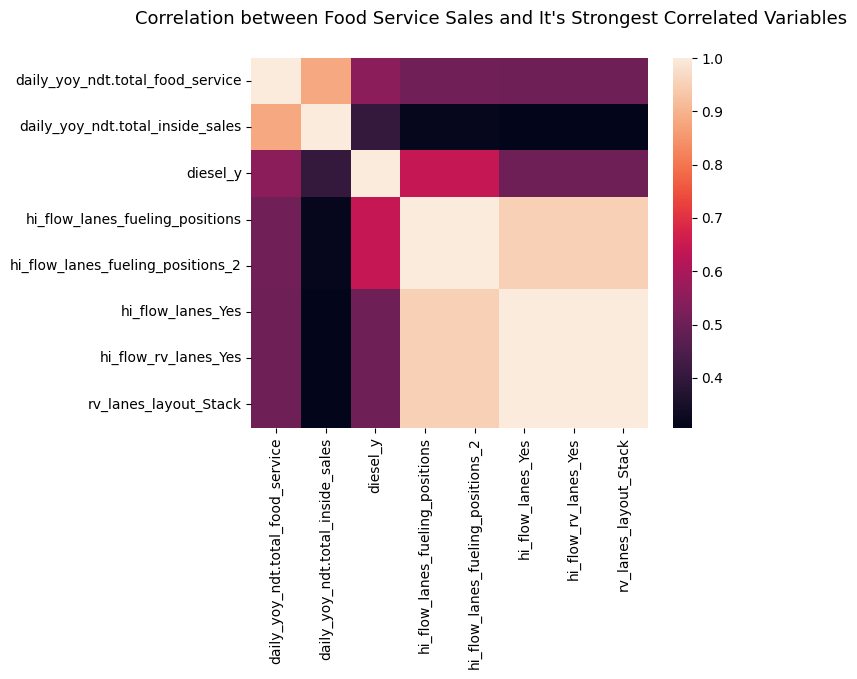

```python
corr_food = df_corr[['daily_yoy_ndt.total_food_service',
                    'daily_yoy_ndt.total_inside_sales',
  'diesel_y',
  'hi_flow_lanes_fueling_positions',
  'hi_flow_lanes_fueling_positions_2',
  'hi_flow_lanes_Yes',
  'hi_flow_rv_lanes_Yes',
  'rv_lanes_layout_Stack']]
sns.heatmap(corr_food.corr())
plt.suptitle('Correlation between Food Service Sales and It\'s Strongest Correlated Variables', fontsize=13)
```

This correlation plot shows the variables with the highest correlation to total food service sales.

# Results

We will review the questions we framed for our analysis and provide summaries of what we learned:

1. **On average, which stores are producing the highest total sales metrics?**

   Store 21980 is showing extremely high diesel sales relative to other stores. We also see that store 22260 has the highest unleaded sales and store 22085 has the highest inside sales. Interestingly, food services sales is very low for all stores and relative to other sales metrics.
2. **Describe the datasets.**

   Qualitative: (37, 55)

   time_series: (13,908, 12)

   Time_Series data includes daily sales data for 37 unique sites with sales date ranging 1/12/2021 - 8/16/2023.
3. **What are sales trends over time? (by month, by week, by day of week, and by holidays)**

   Looking at average sales by day of week, Maverik experiences higher sales on weekdays compared to weekends. Total inside sales and unleaded sales follow an upward trend throughout the week and peak on Friday. Diesel and food service sales remain steady throughout the weekday.

   There are four correlation plots for each sales metric showing its highest correlation to seven variables in the datasets.

   Correlations to highlight: Stores selling pizza to inside sales, stores selling lotteries to unleaded sales.
5. **Are the sales metrics correlated with each other?**

   Overall, every sales metric is positively correlated to each other. The highest correlation is between inside sales and food service sales.
6. **Are there any variables in the datasets that we will not need for our model?**

   These features can be removed as they only have one data value: Front door, god_father_pizza, Diesel, non-24-hr, self_checkout, car_wash, and ev_charging.

   The first column for each dataset has a 'count' for each row in the datasets. This can be removed.
7. **Are there any outliers?**

   One site has higher Diesel sales than others. Four sites seem to have higher sales than average.
8. **Do we have an data imbalances?**

   High data imbalance on feature data like freal, cinnabon, cat_scales,propane, rv_lanes and hi_flow_lanes.

# Contributions

Each team member created an individual EDA notebook and combined visualizations, analysis and results in this notebook.

**Bhoomika John Pedely**:

- Created and organized the google colab notebook and contributed to the business problem statement
- Completed the required data transformations and created data summaries including time series line charts and correlation heatmaps
- Collaborated with team members to complete the final editing of the notebook

**Pablo Zarate**:

- Created the sales by categorical variables charts.
- Helped frame the starting questions, provided analysis for visualizations and provided input for final results.
- Added the table of contents.
- Contributed to the problem statement

**Roman Brock**:

- Created scatter plot correlation between sales variables
- Contributed to the problem statement
- Helped in curating disparate and separate analyses / EDA notebooks
- Worked with team members to assemble our final submission doc

**Biva Sherchan**:

- Made sure to complete my EDA to be ready to dicuss my findings with the team and we collectively created the EDA document for the assignment.
- Helped with outlier detection, data details, time-series charts and visualizations etc.
- Contributed to the problem statement